# TP1 - MATH-60633

2025-02-26

## 📌 Projet

Ce document présente le code R et les résultats du **Travail Pratique 1** du cours **MATH-60633**, enseigné par **David Ardia**.

##### ✍️ Réalisé par :

- **Faycal Berrada**
- **Jérémy Lagacé**
- **Maxime Levasseur-Vandal**

L’objectif de ce travail est **d’estimer et de backtester la Valeur en Risque (VaR)** de deux indices financiers :

- **S&P 500**
- **FTSE 100**

Pour cela, nous utilisons un modèle **GARCH(1,1) avec distribution normale** afin d’évaluer la robustesse des estimations. Ce document détaille le code R utilisé, la méthodologie adoptée, ainsi que les résultats obtenus.

### 🔹 Modèle GARCH(1,1)

Le modèle **GARCH(1,1) avec erreur normale** pour les rendements $y_t$ est défini comme suit :

$$y_t = \sigma_t \epsilon_t, \quad \epsilon_t \sim \text{iid } N(0,1)$$

Avec l’évolution de la variance conditionnelle donnée par :

$$\sigma_t^2 = \omega + \alpha y_{t-1}^2 + \beta \sigma_{t-1}^2$$

## 📌 Les étapes du travail :

### 🔹 Données

```r
# Charger les bibliothèques nécessaires
library(xts)
library(PerformanceAnalytics)
library(parallel)

# Charger les données financières
load("Data/indices.rda")

# Conserver uniquement les données depuis 2005
prices <- prices["2005/"]

# Calcul des rendements logarithmiques
rets <- diff(log(prices))[-1]
```

### 🔹 Fonctions

Cette partie contient les corrections apportées à la fonction **f_forecast_var.R** ainsi que celles apportées aux fonctions qu’elle utilise. Le code dans les prochaines parties fera appel à ces fonctions qui sont dans un autre dossier.

```r
f_forecast_var <- function(y, level) {
  ### Compute the VaR forecast of a GARCH(1,1) model with Normal errors at the desired risk level
  #  INPUTS
  #   y     : [vector] (T x 1) of observations (log-returns)
  #   level : [scalar] risk level (e.g. 0.95 for a VaR at the 95# risk level)
  #  OUTPUTS
  #   VaR   : [scalar] VaR forecast
  #   sig2  : [vector] (T+1 x 1) conditional variances
  #   theta : [vector] GARCH parameters
  #  NOTE
  #   o the estimation is done by maximum likelihood

  # Fit a GARCH(1,1) model with Normal errors
  # Starting values and bounds

  # Valeurs initiales (omega,alpha,beta)
  theta0 <- c(0.1 * var(y), 0.1, 0.8)

  # Lower bounds des valeurs initiales
  LB     <- c(0, 1e-8, 1e-8)

  # Stationarity condition
  A      <- matrix(c(1,  0,  0,  # ω ≥ 0
                     0,  1,  0,  # α > 0
                     0,  0,  1,  # β > 0
                     0, -1, -1   # α + β < 1
                     )
                   , nrow = 4, byrow = TRUE)

  b      <- c(LB,-1 + 1e-8)

  # Run the optimization
  # The feasible region in constrOptim is defined by ui %*% theta - ci >= 0
  theta <- constrOptim(
    theta = theta0,
    f = f_nll,
    grad = NULL,
    ui = A,
    ci = b,
    y = y)$par


  # Recompute the conditional variance
  sig2 <- f_ht(theta, y)

  # Compute the next-day ahead VaR for the Normal model
  VaR <- qnorm(1 - level) * sqrt(sig2[length(sig2)])

  out <- list(VaR_Forecast = VaR,
              ConditionalVariances = sig2,
              GARCH_param = theta)

  out
}
```

```r
f_nll <- function(theta, y) {
  ### Fonction which computes the negative log likelihood value
  ### of a GARCH model with Normal errors
  #  INPUTS
  #   theta  : [vector] of parameters
  #   y      : [vector] (T x 1) of observations
  #  OUTPUTS
  #   nll    : [scalar] negative log likelihood value


  T <- length(y)

  # Compute the conditional variance of a GARCH(1,1) model
  sig2 <- f_ht(theta, y)

  # Consider the T values
  sig2 <- sig2[1:T]

  # Compute the loglikelihood
  ll <- sum(-0.5 * (log(2 * pi) + log(sig2) + (y^2 / sig2)))

  # Output the negative value
  nll <- -ll

  nll
}
```

```r
f_ht <- function(theta, y)  {
  ### Function which computes the vector of conditional variance
  #  INPUTS
  #   x0 : [vector] (3 x 1)
  #   y  : [vector] (T x 1) log-returns
  #  OUTPUTS
  #   sig2  : [vector] (T+1 x 1) conditional variances


  # Extract the parameters
  a0 <- theta[1]  # ω
  a1 <- theta[2]  # α
  b1 <- theta[3]  # β

  T <- length(y)

  # Initialize the conditional variances
  sig2 <- rep(NA, T + 1)

  # Start with unconditional variances
  sig2[1] <- a0 / (1 - a1 - b1)

  # Compute conditional variance at each step
  for (t in 2:(T+1)){
    sig2[t] <- a0 + a1 * (y[t - 1]^2) + b1 * sig2[t - 1]
  }

  sig2
}
```

### 🔹 Estimation statique de la VaR

```r
# Charger les fonctions nécessaires présentées ci-haut pour estimer la VaR
source("Function/f_forecast_var.R")

# Estimation de la VaR avec un historique de 1000 jours
VaR_SP500 <- f_forecast_var(rets[1:1000, "SP500"], 0.95)
VaR_FTSE  <- f_forecast_var(rets[1:1000, "FTSE100"], 0.95)
```

#### 🎯 Résultats de la VaR

Les **VaR** au temps **T+1** sont :

- **S&P500** : -0.0694
- **FTSE100** : -0.0624

> **Le plus risqué est :** **S&P500**

#### 🎯 Paramètres du modèle GARCH(1,1)

Les paramètres estimés du modèle **GARCH(1,1)** pour chaque indice sont :

| Paramètre | S&P500 | FTSE100 |
| --- | --- | --- |
| **$\omega$** | 0.000001 | 0.000001 |
| **$\alpha$** | 0.073234 | 0.122683 |
| **$\beta$** | 0.914928 | 0.863740 |

### 🔹 Backtesting

En appliquant une fenêtre glissante de 1000 jours, la VaR à 95% est estimée à chaque étape en utilisant les 1000 jours précédents comme historique. Cette estimation est répétée sur 1000 jours consécutifs, permettant ainsi de stocker et d’analyser l’évolution de la VaR au fil du temps.

```r
T <- 1000  # Taille de la fenêtre glissante
N <- 1000  # Nombre de jours de backtesting

# Création des N fenêtres roulantes pour faciliter la parallélisation
windows_SP500 <- lapply(seq_len(N), function(i) rets[i:(T + i - 1), "SP500"])
windows_FTSE  <- lapply(seq_len(N), function(i) rets[i:(T + i - 1), "FTSE100"])

# Détection du nombre de cœurs
n_cores <- detectCores()

# Création d'un cluster parallèle
cl <- makeCluster(n_cores - 1)
clusterExport(cl, c("windows_SP500", "windows_FTSE", "f_forecast_var", "f_nll", "f_ht"))

# Calcul des N VaR avec une fenêtre glissante de T jours
VaR_SP500_BT <- parSapply(cl, windows_SP500, function(x) f_forecast_var(x, level = 0.95)[[1]])
VaR_FTSE_BT  <- parSapply(cl, windows_FTSE, function(x) f_forecast_var(x, level = 0.95)[[1]])

# Fermeture du cluster
stopCluster(cl)

# Conversion en objet xts et ajout des dates
dates <- index(rets[(T + 1):(T + N), ])
VaR_SP500_BT <- xts(VaR_SP500_BT, order.by = dates)
VaR_FTSE_BT  <- xts(VaR_FTSE_BT, order.by = dates)

colnames(VaR_SP500_BT) <- "SP500"
colnames(VaR_FTSE_BT)  <- "FTSE100"
```

```r
# Enregistrement des graphiques en PNG
png("Data/Output/VaR_Backtesting.png")

# Enregistrement des résultats du backtest dans une fichier *RDA*
save(VaR_SP500_BT, VaR_FTSE_BT, file = "Data/Output/VaR_Backtesting.rda")
```

#### 🎯 Graphiques des séries de rendements réalisés et les estimations de la VaR

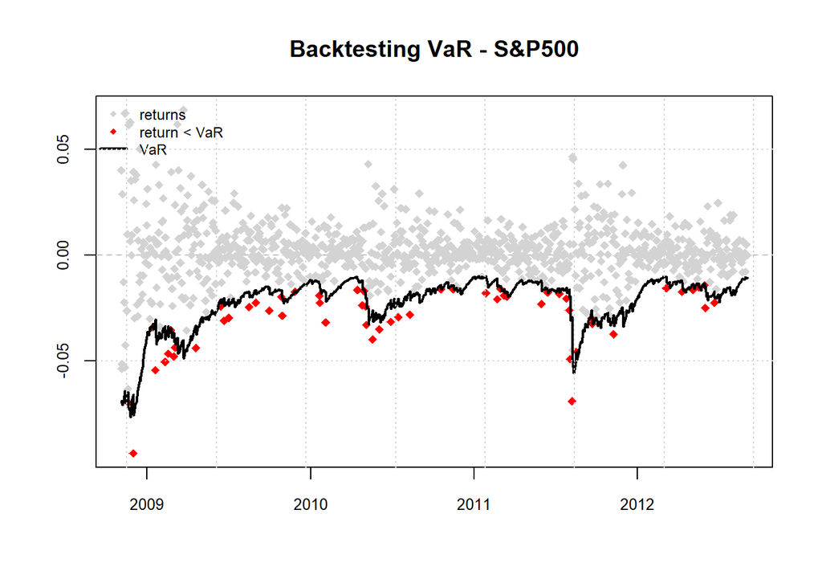

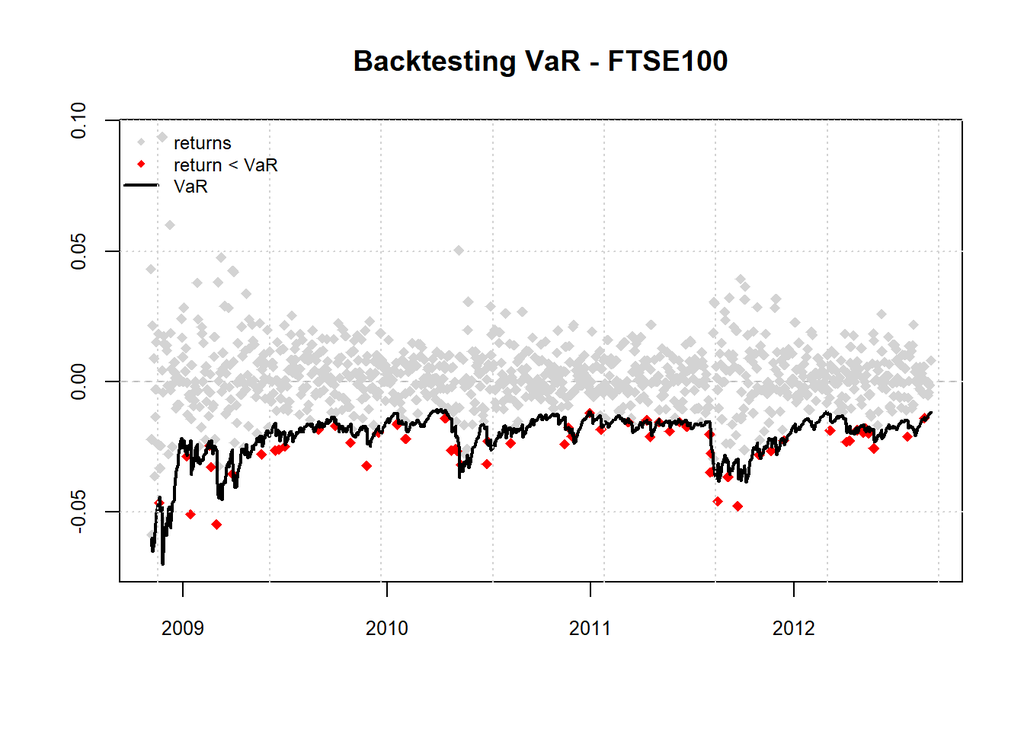

#### 🎯 Pourcentage des rendements sous la VaR

Les pourcentages de rendements sous la **VaR** sont :

> **S&P 500** : 5.7%

> **FTSE 100** : 5.9%